# TP2_Albornoz

Pablo Albornoz

2023-09-23

## Activación de librerías

Activamos las librerías que vamos a utilizar, para poder manipular los datos y visualizarlos en un gráfico.

```r
library(tidyverse)
library(sf)
library(geoAr)
library(janitor)
library(geofacet)
```

## Dataset: Venta de departamentos en CABA

Voy a seguir trabajando con la base de datos BA data sobre departamentos en venta para el año 2020. Directamente cargamos la base de datos con el enlace a la página de [BA data](https://data.buenosaires.gob.ar/dataset/departamentos-venta/resource/e4de7e2b-12af-41fa-832f-7b46e75b44a8) y lo incorporo al *environment* que voy a trabajar con el nombre de Base_Departamentos.

```r
Base_Departamentos <- read_csv("https://cdn.buenosaires.gob.ar/datosabiertos/datasets/secretaria-de-desarrollo-urbano/departamentos-venta/departamentos-en-venta-2020.csv")
```

Analizamos sintéticamente los datos que contiene este dataset:

```r
summary(Base_Departamentos)
```

```
##   Direccion           PropiedadS          Dolares             Pesos
##  Length:156258      Min.   :   11.00   Min.   :    7200   Min.   :4.392e+05
##  Class :character   1st Qu.:   41.00   1st Qu.:  107000   1st Qu.:7.089e+06
##  Mode  :character   Median :   58.00   Median :  150000   Median :1.008e+07
##                     Mean   :   74.18   Mean   :  213947   Mean   :1.439e+07
##                     3rd Qu.:   85.00   3rd Qu.:  235000   3rd Qu.:1.594e+07
##                     Max.   :17180.00   Max.   :17000000   Max.   :1.088e+09
##    DolaresM2        PesosM2          Ambientes        Cotizacion
##  Min.   :  147   Min.   :   9205   Min.   :-7.000   Min.   :61.0
##  1st Qu.: 2250   1st Qu.: 150630   1st Qu.: 2.000   1st Qu.:64.0
##  Median : 2757   Median : 184542   Median : 2.000   Median :67.0
##  Mean   : 2913   Mean   : 195183   Mean   : 2.536   Mean   :67.2
##  3rd Qu.: 3375   3rd Qu.: 225455   3rd Qu.: 3.000   3rd Qu.:70.0
##  Max.   :72917   Max.   :4721354   Max.   : 8.000   Max.   :82.0
##   Trimestre            Barrio             Comunas
##  Length:156258      Length:156258      Min.   : 0.000
##  Class :character   Class :character   1st Qu.: 4.000
##  Mode  :character   Mode  :character   Median :10.000
##                                        Mean   : 8.666
##                                        3rd Qu.:13.000
##                                        Max.   :15.000
```

```r
dim(Base_Departamentos)
```

```
## [1] 156258     11
```

Tenemos un total de 156.258 observaciones (cada fila corresponde a un departamento en venta en CABA), con 11 columnas con datos sobre la dirección, precios, cantidad de ambientes, dirección, entre otras.

Como posteriormente voy a agrupar columnas, me gustaría trabajar los datos de barrio como factor:

```r
Base_Departamentos$Barrio <- as.factor(Base_Departamentos$Barrio)
```

Confirmamos:

```r
summary(Base_Departamentos)
```

```
##   Direccion           PropiedadS          Dolares             Pesos
##  Length:156258      Min.   :   11.00   Min.   :    7200   Min.   :4.392e+05
##  Class :character   1st Qu.:   41.00   1st Qu.:  107000   1st Qu.:7.089e+06
##  Mode  :character   Median :   58.00   Median :  150000   Median :1.008e+07
##                     Mean   :   74.18   Mean   :  213947   Mean   :1.439e+07
##                     3rd Qu.:   85.00   3rd Qu.:  235000   3rd Qu.:1.594e+07
##                     Max.   :17180.00   Max.   :17000000   Max.   :1.088e+09
##
##    DolaresM2        PesosM2          Ambientes        Cotizacion
##  Min.   :  147   Min.   :   9205   Min.   :-7.000   Min.   :61.0
##  1st Qu.: 2250   1st Qu.: 150630   1st Qu.: 2.000   1st Qu.:64.0
##  Median : 2757   Median : 184542   Median : 2.000   Median :67.0
##  Mean   : 2913   Mean   : 195183   Mean   : 2.536   Mean   :67.2
##  3rd Qu.: 3375   3rd Qu.: 225455   3rd Qu.: 3.000   3rd Qu.:70.0
##  Max.   :72917   Max.   :4721354   Max.   : 8.000   Max.   :82.0
##
##   Trimestre               Barrio         Comunas
##  Length:156258      PALERMO  :21702   Min.   : 0.000
##  Class :character   CABALLITO:11358   1st Qu.: 4.000
##  Mode  :character   BELGRANO :11184   Median :10.000
##                     RECOLETA :11137   Mean   : 8.666
##                     ALMAGRO  : 8477   3rd Qu.:13.000
##                     (Other)  :92390   Max.   :15.000
##                     NA's     :   10
```

```r
dim(Base_Departamentos)
```

```
## [1] 156258     11
```

## Mapa base

Estos datos los quiero vincular geospacialmente, por lo que incorporo un mapa de la ciudad de Buenos Aires. Cargamos los polígonos para CABA, descargados de [BA Data](https://data.buenosaires.gob.ar/dataset/barrios/resource/dcd11728-8ec5-4082-a81c-7348ac89a48a). El archivo en SHP lo tenemos descargado en la carpeta del proyecto.

```r
Barrios <- st_read("barrios/barrios_wgs84.shp",
                        stringsAsFactors = TRUE,
                        options = "ENCODING=UTF8")
```

```
## options:        ENCODING=UTF8
```

Vemos que el tipo de geometría es un polígono, y su sistema de coordenadas es WGS 84 (World Geodetic System 1984). El código EPSG 4326 se usa comúnmente para referirse a las coordenadas en este sistema.

Hacemos un resumen de los datos:

```r
summary(Barrios)
```

```
##        BARRIO       COMUNA         PERIMETRO          AREA             OBJETO
##  AGRONOMIA: 1   Min.   : 1.000   Min.   : 4531   Min.   : 1232270   BARRIO:48
##  ALMAGRO  : 1   1st Qu.: 4.000   1st Qu.: 6554   1st Qu.: 2222027
##  BALVANERA: 1   Median : 9.500   Median : 8254   Median : 3679709
##  BARRACAS : 1   Mean   : 8.458   Mean   : 9863   Mean   : 4242703
##  BELGRANO : 1   3rd Qu.:12.000   3rd Qu.:11127   3rd Qu.: 5142993
##  BOCA     : 1   Max.   :15.000   Max.   :22127   Max.   :15845871
##  (Other)  :42
##           geometry
##  POLYGON      :48
##  epsg:4326    : 0
##  +proj=long...: 0
##
##
##
##
```

```r
dim(Barrios)
```

```
## [1] 48  6
```

Lo podemos graficar:

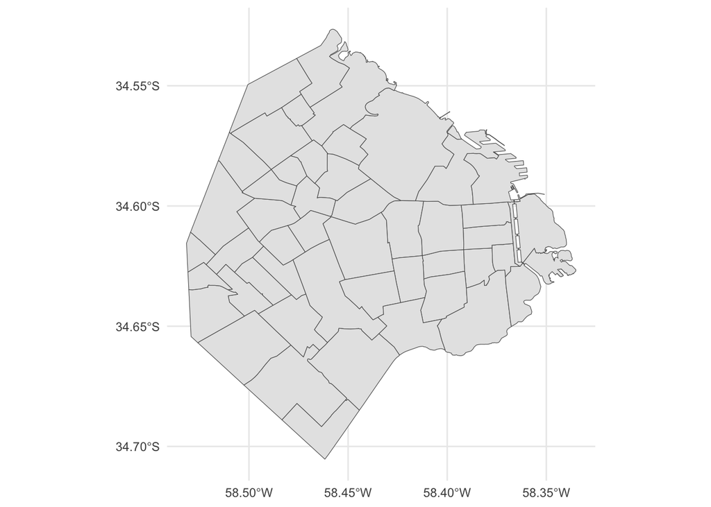

```r
ggplot()+
  geom_sf(data=Barrios)+
  theme_minimal()
```

Limpiamos los dataset, para que coincida el formato del nombre de las columnas y después los podamos unificar.

```r
Departamentos <- Base_Departamentos %>%
  na.omit() %>%
  mutate(Barrio = case_when(
    Barrio %in% c("FLORES NORTE", "FLORES SUR") ~ "FLORES",
    Barrio %in% c("BARRACAS ESTE", "BARRACAS OESTE") ~ "BARRACAS",
    Barrio %in% c("VILLA DEVOTO NORTE", "VILLA DEVOTO SUR") ~ "VILLA DEVOTO",
    Barrio %in% c("MONTSERRAT") ~ "MONSERRAT",
    TRUE ~ Barrio
  )) %>%
  filter(Ambientes>0)
```

```r
Departamentos <- Departamentos %>%
  clean_names()
Barrios <- Barrios %>%
  clean_names()
```

## Transformación de datos

Nuestro objetivo es visualizar información sobre la cantidad y valor de los departamentos (en dólares USD) por barrio en CABA y queremos distinguir su precio según la cantidad de ambientes que tengan.

Para ello, primero trabajamos los datos. Realizamos una agrupación para que nos muestre la cantidad de departamentos en cada barrio, distinguido por cantidad de ambientes. Además, agregamos las columnas relativas al valor promedio en dólares de las unidades, tanto el precio promedio de venta como el precio promedio del metro cuadrado (m2)

```r
Deptos_venta <- Departamentos %>%
  group_by(barrio, ambientes) %>%
  mutate(barrio = str_replace(barrio, "[æ]", "Ñ")) %>%
  mutate(barrio = str_replace(barrio, "[?]", "")) %>%
  summarise(cantidad=n(),
            valor_promedio_usd=mean(dolares),
            dolaresM2=mean(dolares_m2)) %>%
  mutate(dolaresM2 = round(dolaresM2, 2)) %>%
  mutate(barrio = as.factor(barrio))
summary(Deptos_venta)
```

```
##        barrio      ambientes        cantidad    valor_promedio_usd
##  ALMAGRO  :  8   Min.   :1.000   Min.   :   1   Min.   :  45418
##  BALVANERA:  8   1st Qu.:2.000   1st Qu.:  25   1st Qu.: 119829
##  BELGRANO :  8   Median :4.000   Median : 185   Median : 191609
##  CABALLITO:  8   Mean   :3.751   Mean   : 526   Mean   : 298372
##  MONSERRAT:  8   3rd Qu.:5.000   3rd Qu.: 620   3rd Qu.: 325000
##  PALERMO  :  8   Max.   :8.000   Max.   :6862   Max.   :3300000
##  (Other)  :249
##    dolaresM2
##  Min.   : 594.6
##  1st Qu.:1964.5
##  Median :2370.8
##  Mean   :2484.9
##  3rd Qu.:2805.0
##  Max.   :8049.0
##
```

```r
dim(Deptos_venta)
```

```
## [1] 297   5
```

## Visualización de datos

### Cantidad total de departamentos

Vemos la cantidad de departamentos que estaban en venta en CABA durante 2020.

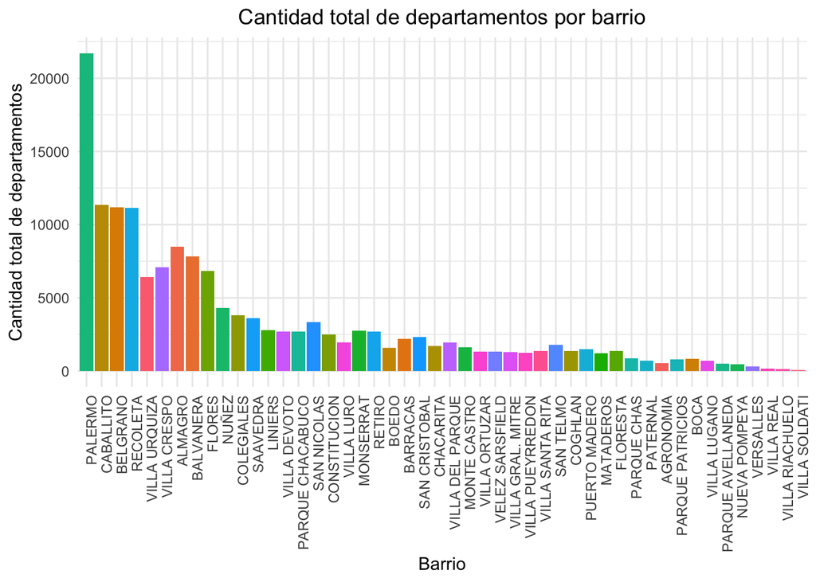

```r
ggplot(Deptos_venta, aes(x = reorder(barrio, -cantidad), y = cantidad, fill = barrio)) +
  geom_bar(stat = "identity") +
  labs(title = "Cantidad total de departamentos por barrio",
       x = "Barrio",
       y = "Cantidad total de departamentos") +
  theme_minimal()+
  guides(fill = FALSE)+
  theme(axis.text.x = element_text(angle = 90, hjust = 1),
        plot.title = element_text(hjust = 0.5))
```

Esto podemos visualizarlo en un mapa también, sin embargo, voy a reagrupar los datos para que haya una sola fila por barrio que esté georreferenciada. Por lo tanto, agrupamos solo por barrio.

```r
Deptos_venta_barrio <- Departamentos %>%
  group_by(barrio) %>%
  mutate(barrio = str_replace(barrio, "[æ]", "Ñ")) %>%
  mutate(barrio = str_replace(barrio, "[?]", "")) %>%
  summarise(cantidad=n(),
            valor_promedio_usd=mean(dolares),
            dolaresM2=mean(dolares_m2)) %>%
  mutate(dolaresM2 = round(dolaresM2, 2)) %>%
  mutate(barrio = as.factor(barrio))
```

Ahora a esta le agrego la georreferencia espacial:

```r
Deptos_venta_geo <- left_join(Barrios, Deptos_venta_barrio, by="barrio")
```

Ahora podemos graficar en un mapa, donde la graduación de color nos indica la cantidad de departamentos (más oscuro, más departamentos en venta):

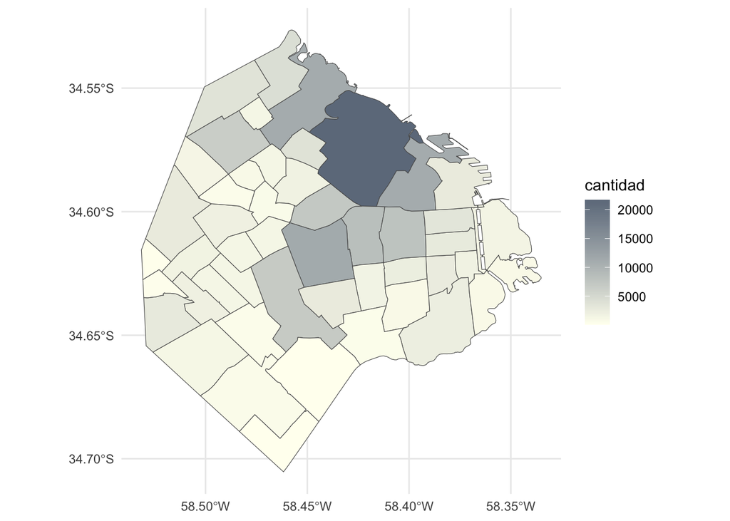

```r
ggplot()+
  geom_sf(data=Deptos_venta_geo, aes(fill=cantidad))+
  scale_fill_gradient(low = "ivory", high = "lightsteelblue4") +
  theme_minimal()
```

### Precio promedio de los departamentos

Ahora también podemos ver el valor promedio de todos los deptos en venta.

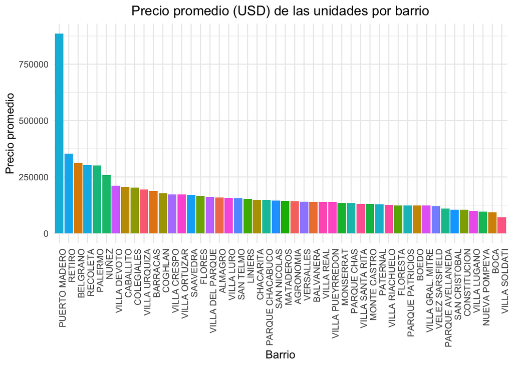

```r
ggplot(Deptos_venta_barrio, aes(x = reorder(barrio, -valor_promedio_usd), y = valor_promedio_usd, fill = barrio)) +
  geom_bar(stat = "identity") +
  labs(title = "Precio promedio (USD) de las unidades por barrio",
       x = "Barrio",
       y = "Precio promedio") +
  theme_minimal()+
  guides(fill = FALSE)+
  theme(axis.text.x = element_text(angle = 90, hjust = 1),
        plot.title = element_text(hjust = 0.5))
```

En este caso, los departamentos de Puerto Madero son los de mayor precio, por encima de los 750 mil dólares promedio. Villa Soldati, en tanto, es la que ofrece los departamentos de menor valor.

Vemos esta información en un mapa:

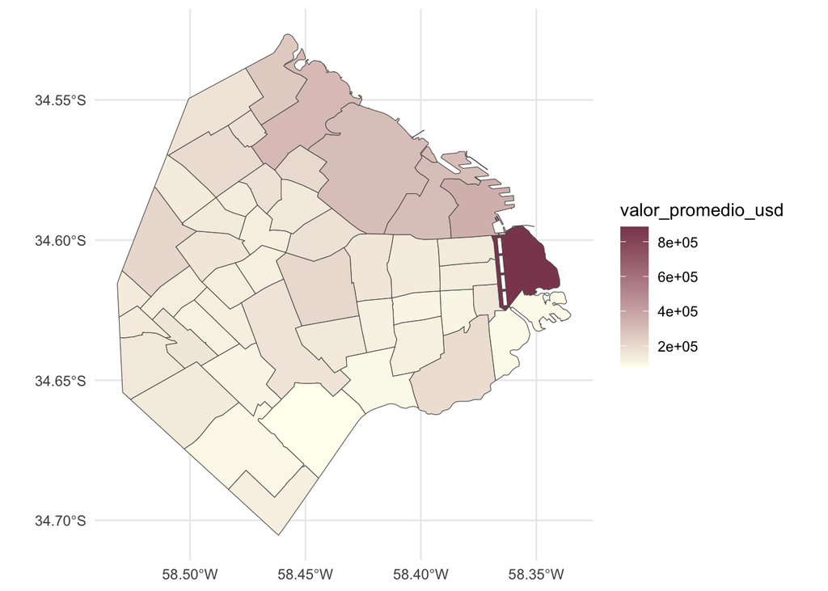

```r
ggplot()+
  geom_sf(data=Deptos_venta_geo, aes(fill=valor_promedio_usd))+
  scale_fill_gradient(low = "ivory", high = "palevioletred4") +
  theme_minimal()
```

## Cantidad de departamentos según cantidad de ambientes por barrio

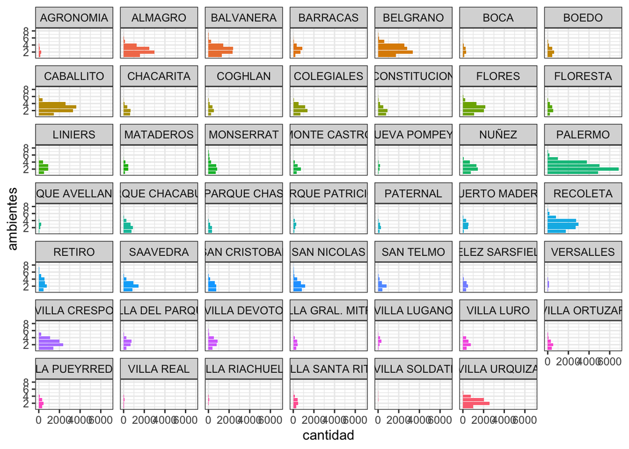

```r
ggplot(Deptos_venta, aes(ambientes, cantidad, fill=barrio))+
  geom_col()+
  coord_flip()+
  theme_bw()+
  facet_wrap(~ barrio)+
  guides(fill = FALSE)
```

Aquí vemos los gráficos dividido por barrio, en donde se puede observar la cantidad de departamentos que hay según su cantidad de ambientes. Podemos ver más en específico, por ejemplo, los barrios de Palermo, Caballito, Belgrano, Recoleta, Almagro, que son los que mayor oferta tienen, e incluyo Puerto Madero.

```r
selección <- Deptos_venta %>%
  filter(barrio == "PALERMO" | barrio == "CABALLITO" | barrio == "BELGRANO"| barrio == "RECOLETA"| barrio == "ALMAGRO"| barrio == "PUERTO MADERO")
```

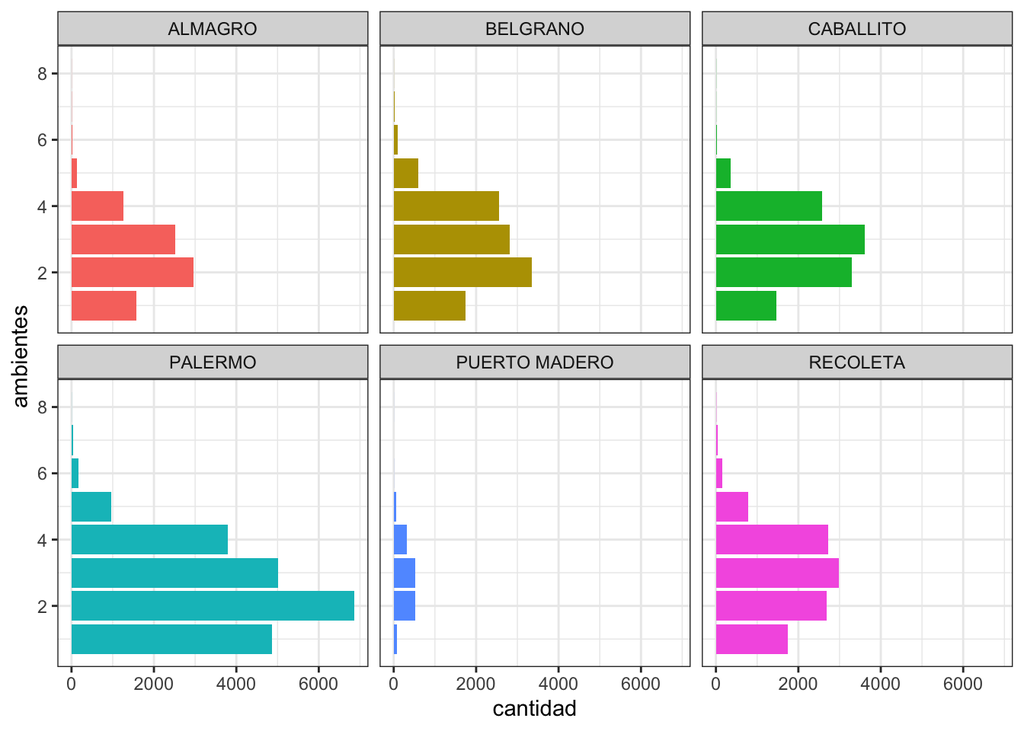

```r
ggplot(selección, aes(ambientes, cantidad, fill=barrio))+
  geom_col()+
  coord_flip()+
  theme_bw()+
  facet_wrap(~ barrio)+
  guides(fill = FALSE)
```

En este caso, podemos ver que cambia un poco el perfil del tipo de unidad en venta. Mientras que en Palermo y Belgrano predominan los departamentos de 2 ambientes, En Recoleta y Caballito son los de tres ambientes.

## Precio promedio de venta según cantidad de ambientes

¿Y qué pasa con los valores en cada barrio de las unidades en venta según su cantidad de ambientes?

Lo vemos en el siguiente gráfico:

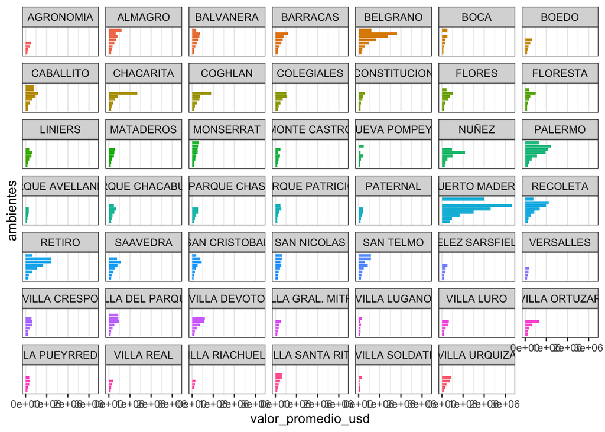

```r
ggplot(Deptos_venta, aes(ambientes, valor_promedio_usd, fill=barrio))+
  geom_col()+
  coord_flip()+
  theme_bw()+
  facet_wrap(~ barrio)+
  guides(fill = FALSE)+
  scale_x_discrete(labels = scales::label_comma())
```

Aquí se puede ver el caso de Puerto Madero, el barrio con las unidades más caras.

En detalle, de los barrios seleccionados anteriormente:

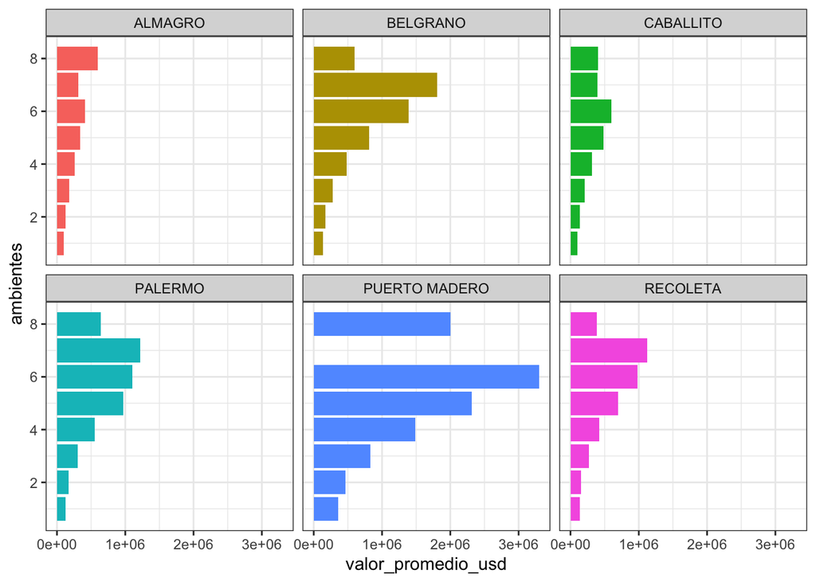

```r
ggplot(selección, aes(ambientes, valor_promedio_usd, fill=barrio))+
  geom_col()+
  coord_flip()+
  theme_bw()+
  facet_wrap(~ barrio)+
  guides(fill = FALSE)
```